# KNN概述

**“物以类聚，人以群分”，同类东西常常放在一起，志同道合的人也常常走在一起。knn算法就是这种思想，要想知道一个东西的类别，可以通过它周围的事物来反映。knn算法是一种分类算法，基于实例的学习（instance-based learning）和懒惰学习（lazy learning）**。

```
       kNN算法的核心思想是如果一个样本在特征空间中的k个最相邻的样本中的大多数属于某一个类别，则该样本也属于这个类别，并具有这个类别上样本的特性。该方法在确定分类决策上只依据最邻近的一个或者几个样本的类别来决定待分样本所属的类别。 kNN方法在类别决策时，只与极少量的相邻样本有关。由于kNN方法主要靠周围有限的邻近的样本，而不是靠判别类域的方法来确定所属类别的，因此对于类域的交叉或重叠较多的待分样本集来说，kNN方法较其他方法更为适合。
```

**下面引入一个实例,理解下KNN**:

如下图，绿色圆要被决定赋予哪个类，是红色三角形还是蓝色四方形？如果K=3，由于红色三角形所占比例为2/3，绿色圆将被赋予红色三角形那个类，如果K=5，由于蓝色四方形比例为3/5，因此绿色圆被赋予蓝色四方形类。

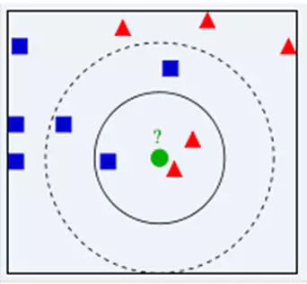

如上可以看出，knn算法最关键的两个地方就是k的选取以及距离的计算

# 算法步骤

1. 计算测试数据与训练集各数据之间的距离

关于距离的度量方法，常用的有：欧式距离(Euclidean distance)，余弦值（cos）, 相关度 （correlation）, 曼哈顿距离(Manhattan distance)或街区距离(cityblock distance)，闵可夫斯基距离(Minkowski distance)，切比雪夫距离(Chebyshev distance)，汉明距离(Hamming distance)或其他。其中欧氏距离最为常用

1. 根据距离远近排序
2. 自定义K并选取离测试数据最近的K个点
3. 返回前K个点钟出现频率最高的类别作为该测试数据的类别:多数表决法：

   多数表决法类似于投票的过程，也就是在 K 个邻居中选择类别最多的种类作为测试样本的类别。

   ```
    )2加权表决法：根据距离的远近，对近邻的投票进行加权，距离越近则权重越大，通过权重计算结果最大值的类为测试样本的类别。
   ```

# 代码实现

## 已知有一组数据：为人头发的长度，其中23,15,27,40,40,20cm 为调查的女生头发长度6,20,12,3,16,15cm 是调查的男生头发长度。请根据这一组数据，判断小明（头发长18cm）的性别：

```python
z2=[23,15,27,40,40,20]#z2为女生头发长度
z1=[6,20,12,3,16,15]#z1是男生头发长度
z=18#小明头发的长度
distance1,distance2=0,0
ls={}
k=5#k的设定
n=0
def knn(z1,z2,z,k):
    ls={}
    n=0

for i in range(len(z1)):
    distance1=(z1[i]-z)**2#距离的计算
    distance2=(z2[i]-z)**2

    ls[distance1]=1
    ls[distance2]=2#采用字典的方式
items=list(ls.items())#.items返回可遍历的(键, 值) 元组数组
items.sort(reverse=True)
for j in range(k):
    if items[i][1]==1:
        n+=1
k=5
print("IF k=5,")
if n>3:
    print("He is a boy")
else:
    print("She is a girl")
k=3
print("IF k=3,")
if n>2:
    print("He is a boy")
else:
    print("She is a girl")
knn(z1,z2,z,k)
```

```
IF k=5,
She is a girl
IF k=3,
She is a girl
```

## 多种属性的解决方案，请根据下面表格预测最后一个人的性别：

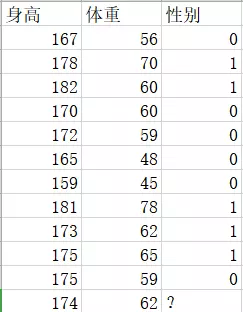

```
She is a girl
```

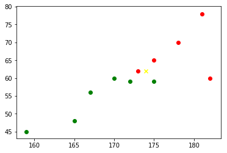

```python
import numpy as np
import matplotlib.pyplot as plt
%matplotlib inline
data=np.array([[167,56],
[178,70],
[182,60],
[170,60],
[172,59],
[165,48],
[159,45],
[181,78],
[173,62],
[175,65],
[175,59]])
sex=np.array([0,1,1,0,0,0,0,1,1,1,0])
k=3
test=[174,62]

def guiyi(data):#数据归一化处理****1
    distract=[]
    mins=data.min(0)
    maxs=data.max(0)
    distract=maxs-mins

    mate=np.zeros(np.shape(data))#构造一个跟data结构一样的矩阵
    line=data.shape[0]#多少行
    mate=data-mins#用data减去差值（矩阵相减）
    #>>> tile([1,2],2)
    #array([1, 2, 1, 2])
    #>>> tile([1,2],(2,2))
    #array([[1, 2, 1, 2],
    #  [1, 2, 1, 2]])
    #np.tile(data,(3,2))复制3行，每行复制两次

    #array([[167,  56, 167,  56],
    ''' [178,  70, 178,  70],
       [182,  60, 182,  60],
       [167,  56, 167,  56],
       [178,  70, 178,  70],
       [182,  60, 182,  60],
       [167,  56, 167,  56],
       [178,  70, 178,  70],
       [182,  60, 182,  60]])'''

    mate=mate/np.tile(distract,(line,1))#然后再除以差值
    return mate,distract,mins
def oushi(test,data,sex,k):#欧式距离法
    line=data.shape[0]
    distances=(np.tile(test,(line,1))-data)**2
    Sum_distance=distances.sum(axis=1)
    placing=Sum_distance.argsort()#返回名次
    times={}
    for i in range(data.shape[0]):
        if placing[i]<k:
            times[sex[i]]=times.get(sex[i],0) + 1

    items=list(times.items())
    items.sort(key=lambda x:x[1],reverse=True)
    return items[0][0]

def knn(test):

    mate,distract,mins=guiyi(data)
   ###将训练集数据归一法得到处理后的数据
    test=np.array(test)

    nort=(test-mins)/distract
    #同理，将测试数据归一化处理

    result=oushi(test,data,sex,k)

    return result
if knn(test)==1:
    print("He is a boy")
else :
    print("She is a girl")

n=-1
ls1=[]
ls2=[]
for i in sex:

    n+=1
    if i==0:
        ls1.append(data[n])
    if i==1:
        ls2.append(data[n])
for i in range(len(ls1)):
    plt.scatter(ls1[i][0],ls1[i][1],color = 'green',label='girl')
for i in range(len(ls2)):
    plt.scatter(ls2[i][0],ls2[i][1],color = 'red',label='boy')
plt.scatter(174,62,marker='x',color='yellow')
plt.show()
```

**注意**：算法中数据归一化 机器学习模型被互联网行业广泛应用，如排序、推荐、反作弊、定位等。一般做机器学习应用的时候大部分时间是花费在特征处理上，其中很关键的一步就是对特征数据进行归一化，为什么要归一化呢？维基百科给出的解释：

1）归一化后加快了梯度下降求最优解的速度；

2）归一化有可能提高精度。

在knn算法中主要是可以用来提高结果的准确度。